# Machine learning course work

Rong Guang

# E3

# Problem 17 *[9 points]*

Objectives: k-means loss and Lloyd’s algorithm

In this problem, you will study the (naive) k-means algorithm (Lloyd’s algorithm). You should be able to solve this problem with a pen and paper. See Section 12.4.1 of ISLR_v2.

## Problem 17: Task a

### Question

Answer the following:

1. For what kinds of tasks can we use the k-means algorithm? 2. What are the algorithm’s inputs and outputs?
2. How should you interpret the results?

### Answer

## Problem 17: Task b

### Question

Define the objective (or cost) function the k-means algorithm tries to minimise.

What can you say about the objective function’s value during the algorithm iteration?

### Answer

## Problem 17: Task c

### Question

Consider the following toy data set:

|  | 1 | 2 | 3 | 4 | 5 |
| --- | --- | --- | --- | --- | --- |
| x | 0 | 1 | 4 | 5 | 5 |
| y | 1 | 2 | 5 | 3 | 4 |

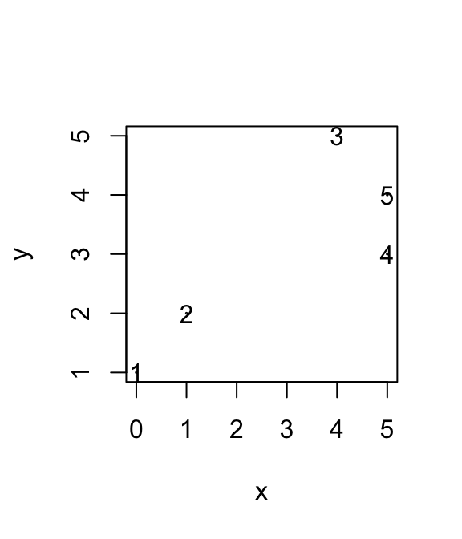

Sketch a run of the (naive) k-means algorithm using 𝐾 = 2 and initial prototype (mean) vectors 𝜇1 = (0, 2) and 𝜇2 = (2, 0). Write down the calculation procedure at each iteration and report the cluster memberships, the prototype vectors, and the value of the objective function at each iteration.

# Problem 18

## Problem 18: Task a

# Problem 19 *[9 points]*

Objectives: practical application of k-means and hierarchical clustering For this problem, you will apply clustering on a subset of the project data (mol.csv). See Section 12.5.3 of ISLR_v2. When clustering the data, omit the columns parentspecies and pSat_Pa, and scale the other variables to zero mean and unit variance unless otherwise instructed. You should use library functions, such as kmeans in R and sklearn.cluster.KMeans in Python. Note: In R, kmeans uses the Hartigan-Wong algorithm by default, so set algorithm=“Lloyd” to use Lloyd’s algorithm. Python’s KMeans uses kmeans++ as the default initialization, so set init=“random” to use random initialisation in Task b.

## Problem 19: Task a

### Question

Plot (or report in a table) the k-means loss as a function of the number of clusters from 1 to 20 for scaled and non-scaled data. Should you scale the columns? How does scaling the columns affect the result?

### Answer

## Problem 19: Task b

### Question

The initialisation of k-means can affect the solution.

Cluster the data with k-means using 𝑘 = 5 with 1000 different random initialisations, and then answer the following:

• What are the minimum and maximum k-means losses for your 1000 random initialisations?

• How many initialisations would you expect to have to obtain one reasonably good loss for this data set and number of clusters? A suﬀiciently good loss here is a solution with a loss within 1% of the best loss out of your 1000 losses.

• How do we deal with the effect of initialization when using k-means in practice?

Make a histogram of the losses.

### My answer

## Problem 19: Task c

### Question

Task c (i) Cluster the data with agglomerative hierarchical clustering using single, complete, and Ward linkage. Produce their dendrograms side-by-side.

2. Find and report at least one interesting feature or reproduce some properties of hierarchical clustering discussed in the class or the textbook. For example, you can show differences between the linkage functions by comparing cluster sizes in different flat clusterings (cutree in R, scipy.cluster.hierarchy.cut_tree in Python).

### answer

# Problem 20 *[9 points]*

In this problem, you will apply Principal Component Analysis (PCA) to mol.csv. See Sect. 12.2.4 of ISLR_v2. When computing PCA on the data, omit the columns parentspecies and pSat_Pa, and scale the other variables to zero mean and unit variance unless otherwise instructed.

## Problem 20: Task a

### Question

Compute and show a PCA projection of the data into two dimensions. Indicate the parent species (column parentspecies) by the point’s colour and shape. Remember to include a legend that indicates which colour/shape corresponds to which class. What does the plot imply about the relationship between parentspecies and the other variables?

### My answer

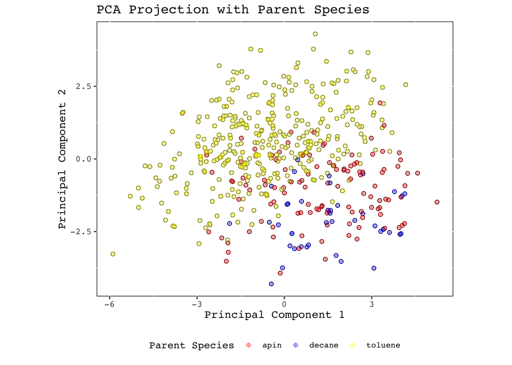

Although there’s considerable overlap between points of different Parent Species, noticeable patterns exist in the distribution of the points along the principal component axes:

-Species ‘decane’ and ‘toluene’ forms different clusters, suggesting they have unique molecular signatures that are captured by the principal components.

-Species `decane` and `apin` are clustered less distinctively than they are to species `toluene`, indicating share certain molecular characteristics that are significantly different from `toluene` in terms of features captured by PC1 and PC2.

-Species `toluene` distributed across both PCs evenly,indicating its molecular properties with highest variance can be equally and nicely represented by PC1 and PC2 nicely.

-Whereas, species `decane` and `apin` distribute mostly across the right end of PC1 axis and lower end of PC2 axis, suggesting most varying features are captured by a portion of PC1 and PC2 and these portions play a role in differentiating them from `toluene`

## Problem 20: Task b

### Question

Plot (or report in a table) the proportion of variance explained (PVE), and the cumulative PVE for the principal components for scaled and un-scaled data.

Why does it seem that fewer components explain a large proportion of the variance for un-scaled data compared to the scaled data?

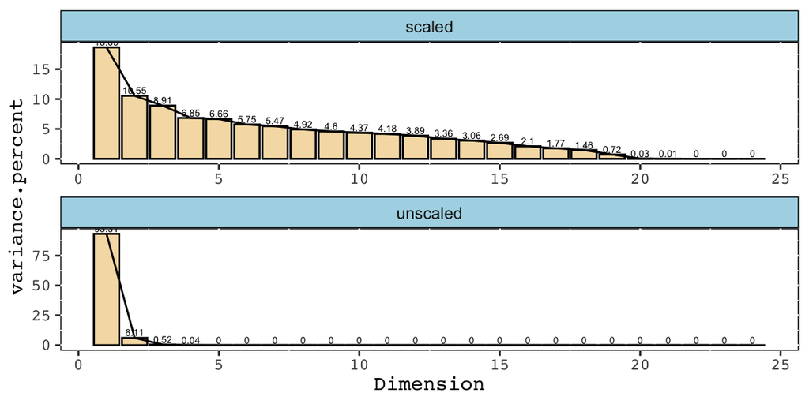

### My answer

## Problem 20: Task c

### Questions

In this task, you will use ordinary least-squares linear regression to predict log10(pSat_Pa) using all variables except parentspecies. Use the random split of mol.csv in files mol_train.csv and mol_validation.csv we have provided. (i) Train the model on the training set mol_train.csv (without dimensionality reduction) and report the RMSE on the validation set mol_validation.csv.

2. Repeat (i) after reducing the dimensionality with PCA for all dimensions ${0, 1, ... , p}$, where 𝑝 is the number of covariates, and report the RMSE values in a table or a plot. How does your model’s performance vary with the (reduced) dimensionality? Is there an “optimal” dimensionality which gives you the best performance on the validation set? Hint: the dimensionality zero means here that your covariates should consist only of the intercept term (i.e., you have no PCA components).
3. What is the smallest dimensionality that gives you a validation set RMSE that is at most 1% larger than the RMSE on dimensionality with the smallest RMSE? Argue why this dimensionality could be a better choice to learn a model than the “optimal” dimensionality you found in subtask (ii) above. Hint: You can just mention here that the loss you got in subtask (ii) is already the smallest dimensionality within 1% of the best validation loss if this is your result. Tip: Notice that you can apply PCA on the combined training and validation sets to utilise the structure of the validation set even if you don’t know the class labels; this is a simple form of semi-supervised learning.

### My answer

# Problem 21 *[2 points]*

## Problem 21: Task a

### Question

Write a learning diary of the topics of lectures 9–10 and this exercise set.

Guiding questions: What did I learn? What did I not understand? Was there something relevant to other studies or (future) work? Your reply should be 1-3 paragraphs of text. You can also give feedback on the course.

### Answer